# IST 5520 Milestone 3: Data Analysis II

## By: Alaina Martens, Aaron Tucker, Kwamena Ato Quainoo, Oluwatosin Martins Waleola 12/04/2022

### Introduction:

Crime has proven to significantly influence the life pattern of people in a given community. Community life, people’s choice of work, living and shopping are actively impacted by this canker. Many research confirms that the rate of crime is highly centered in special or “hotspot” areas in cities. These active places have been reported to be the primary sources from where crimes spread throughout an entire city. Herein, we investigated the effects of these “hotspot” centers on the spread of crime in the city of Boston. Data from the Boston Police Department was collected and employed to develop a predictive model that evaluates the relationship between shootings and special locations in the city of Boston. The work is highly significant as it highlights the relevance of places in the decision making processes of robbers and other reported crimes. Knowledge of this information is bound to help all in the crime-fighting agencies including other stakeholders such as businessmen, landlords, and other employers with necessary information needed to combat and prevent crime in the city of Boston. This will go a long way to improve the culture and living of the people in the city.

### Literature Review:

There exist several reviews investigating the relationship between city hotspot centers and their contribution to the growing crime rate. In 2004, a research team from the University of Maryland investigated crime incidents for 14 years at the level of street segments in Seattle. They found out consistently on a year-by-year basis that over 50 percent of crime in the City of Seattle was significantly concentrated in approximately 4.5 percent of street segments (Weisburd et al. 2004). These analyses revealed high crime stability in city hotspot centers over time. Furthermore, Braga et.al 2011 investigated the impact of hotspots on crime in the city of Boston. They highlighted that crime rates are highly concentrated in micro places and hotspots. Their finding suggests the need for concentrated efforts on specific places (hotspots) rather than increasing policing efforts for the whole city (Braga, Hureau, and Papachristos 2011). Several studied theories show that increased crime rates in communities are heavily linked to more alcohol outlets in these hotspot centers. Research confirms the complex relationship and association between alcohol outlet density and violent crimes. Also, further observations predict neighborhoods with increasing cases of violent crime rates were observed to be of lower income and in areas with less guardianship (Lipton, Yang, Braga, Goldstick, Newton, Rura 2012).

### Research Questions:

There are several problems that we are hoping to address with this particular dataset on crime incidents in the Boston area. A question we would like to answer is if shootings are increasing in the Boston area. From there, we would like to better understand where the shootings are occuring in various areas across the city based on their district, street, even as detailed as their exact geographical location using latitude and longitude data. Once we have a better understanding of what the data looks like and is telling us, we would like to use this as a way to make inferences based on the data as to when and where we can expect shootings will occur. We are also interested in looking into if there is a correlation between the incident location (place where the shooting physically took place) and the reporting area (area where crime was reported from). With this model we would, in layman's terms, be able to “predict” shooting, although we are really just using the data to say “Based on this previous data, we can infer/expect shooting to increase/decrease this much over this amount of time and here is what types of crimes that involves. Along with the aforementioned, we hope to shed light on specific areas within Boston that have higher crime occurrences that may need more resources than other areas in the city in the future.

### Data:

The data sources that we will be using for the project are the Crime Incident Reports from August 2015 - Current date. There are 8 reports, one for each year, and 18 columns in each. These reports are provided by the Boston Police Department of incidents that their officers attended to. These reports focus heavily on the location and time that a crime incident has occured. A more in-depth analysis of the dataset is included below in the crime incidents data dictionary. The data dictionary will explain each column in detail.

| Column Name | Column Description |
| --- | --- |
| _id | A unique, numerical id number that is assigned to every case by the database that represents that specific case |
| INCIDENT_NUMBER | Internal Boston Police Department report number |
| OFFENSE_CODE | Numerical code of offense description |
| OFFENSE_CODE_GROUP | Internal categorization of offense_description |
| OFFENSE_DESCRIPTION | Primary descriptor of incident |
| DISTRICT | What district the crime was reported in the city of Boston |
| REPORTING_AREA | RA number associated with the where the crime was reported from |
| SHOOTING | Indicated a shooting took place |
| OCCURED_ON_DATE | Earliest date and time the incident could have taken place |
| YEAR | Year incident took place |
| MONTH | Month incident took place |
| DAY_OF_WEEK | Day of the week incident took place (Monday, Tuesday, etc.) |
| HOUR | Hour the incident took place |
| UCR_PART | Universal Crime Reporting Part number (1,2,3) |
| STREET | Street name the incident took place at in the city of Boston |
| Lat | The latitude where the incident took place in the city of Boston |
| Long | The longitude where the incident took place in the city of Boston |
| Location | The latitude and longitude together marking the exact location where the incident occured in the city of Boston |

Based on the columns above the crime incidents dataset deems appropriate for helping address our research questions about being able to predict locations of concern where crime incidents may be more likely to occur. The crime incidents reports include columns about the district, reporting area, street address, latitude, longitude, and location. The ability of having the exact location down to the latitude and longitude will allow our group to analyze very specific micro regions and allow the possibility of having a very accurate prediction of where crimes will occur. On top of having an accurate location the reports also have very precise data and times included. Columns such as occured_on_date, year, month, day_of_the_week, and hour will support our ability to predict at what days and times these crimes are occurring in these distinct locations. The reports allow us to possibly predict down to the minute where a crime may occur. Thus the crime incidents dataset provides an ideal source for helping address our research questions pertaining to where and when crime incidents are occuring in Boston.

## Data Manipulation:

Upon importing 2015-2022 Boston crime incident reports into Python we found that our data was mainly qualitative or categorical variables. As we began cleansing the data we came across a lot of issues that would affect how we would use the data for visualization. The major issue though was in the 2015-2018 data they used OFFENSE_CODE_GROUP and UCR_PART but they did not in 2019-2022 and instead entered ‘None’ into the dataset. Due to this issus we decided the best course of action was to delete both of the columns from our dataset. The next issue that occurred was that in 2015-2018 data in the SHOOTING column they used Y to indicate there had been a shooting and NONE to indicate no shooting but in the 2019-2022 data they used 1 for yes and 0 for no. We had to reconfigure the entire SHOOTING column for 2015-2018 data to replace the Y and NONE with 1 and 0. We then went in to the Location column and got rid of the ‘(‘ and ‘)’ around the latitude and longitude.

The next issue that we ran into while manipulating the data was most of the data was qualitative data and wasn’t interval or ratio data. This made it hard to normalize the data and do principal component analysis as there were no numerical data types. We then created multiple frequency tables to evaluate the data. We found this to be the easiest method to analyze the data because it provided us with counts of each qualitative value. Below there are two frequency tables. One is OFFENSE_CODE and YEAR which shows us how many of a certain type of offence occurs in a particular year. The other frequency table shows how many certain types of offenses occur based on offense code occur at a certain hour of the day. As shown below is the data manipulation and cleansing that we did to prepare our data.

### Importing Data

```python
# Import modules
import pandas as pd
import numpy as np
import statsmodels.api as sm
import matplotlib.pyplot as plt
import seaborn as sns
from sklearn.preprocessing import scale
from sklearn.decomposition import PCA

# Configure inline mode
%matplotlib inline
```

```python
dat2015 = pd.read_csv("crime-incident-reports-2015.csv")
dat2016 = pd.read_csv("crime-incident-reports-2016.csv")
dat2017 = pd.read_csv("crime-incident-reports-2017.csv")
dat2018 = pd.read_csv("crime-incident-reports-2018.csv")
dat2019 = pd.read_csv("crime-incident-reports-2019.csv")
dat2020 = pd.read_csv("crime-incident-reports-2020.csv")
dat2021 = pd.read_csv("crime-incident-reports-2021.csv")
dat2022 = pd.read_csv("crime-incident-reports-2022.csv")
```

### Creating Consistency Between Years

```python
dat2015['SHOOTING']=dat2015['SHOOTING'].map({'Y': 1, 'None': 0})
dat2015['SHOOTING']=dat2015['SHOOTING'].fillna(0)
dat2015['Lat']=dat2015['Lat'].fillna(0)
dat2015['Long']=dat2015['Long'].fillna(0)
dat2015['SHOOTING']=dat2015['SHOOTING'].astype('int')
dat2016['SHOOTING']=dat2016['SHOOTING'].map({'Y': 1, 'None': 0})
dat2016['SHOOTING']=dat2016['SHOOTING'].fillna(0)
dat2016['Lat']=dat2016['Lat'].fillna(0)
dat2016['Long']=dat2016['Long'].fillna(0)
dat2016['SHOOTING']=dat2016['SHOOTING'].astype('int')
dat2017['SHOOTING']=dat2017['SHOOTING'].map({'Y': 1, 'None': 0})
dat2017['SHOOTING']=dat2017['SHOOTING'].fillna(0)
dat2017['Lat']=dat2017['Lat'].fillna(0)
dat2017['Long']=dat2017['Long'].fillna(0)
dat2017['SHOOTING']=dat2017['SHOOTING'].astype('int')
dat2018['SHOOTING']=dat2018['SHOOTING'].map({'Y': 1, 'None': 0})
dat2018['SHOOTING']=dat2018['SHOOTING'].fillna(0)
dat2018['Lat']=dat2018['Lat'].fillna(0)
dat2018['Long']=dat2018['Long'].fillna(0)
dat2018['SHOOTING']=dat2018['SHOOTING'].astype('int')
```

```python
dat2015.SHOOTING.unique()
```

```
array([0, 1])
```

```python
dat2015.info()
```

```
<class 'pandas.core.frame.DataFrame'>
RangeIndex: 53597 entries, 0 to 53596
Data columns (total 17 columns):
 #   Column               Non-Null Count  Dtype
---  ------               --------------  -----
 0   INCIDENT_NUMBER      53597 non-null  object
 1   OFFENSE_CODE         53597 non-null  int64
 2   OFFENSE_CODE_GROUP   53597 non-null  object
 3   OFFENSE_DESCRIPTION  53597 non-null  object
 4   DISTRICT             53468 non-null  object
 5   REPORTING_AREA       53597 non-null  object
 6   SHOOTING             53597 non-null  int32
 7   OCCURRED_ON_DATE     53597 non-null  object
 8   YEAR                 53597 non-null  int64
 9   MONTH                53597 non-null  int64
 10  DAY_OF_WEEK          53597 non-null  object
 11  HOUR                 53597 non-null  int64
 12  UCR_PART             53595 non-null  object
 13  STREET               52325 non-null  object
 14  Lat                  53597 non-null  float64
 15  Long                 53597 non-null  float64
 16  Location             53597 non-null  object
dtypes: float64(2), int32(1), int64(4), object(10)
memory usage: 6.7+ MB
```

```python
dat2022.head()
```

|  | INCIDENT_NUMBER | OFFENSE_CODE | OFFENSE_CODE_GROUP | OFFENSE_DESCRIPTION | DISTRICT | REPORTING_AREA | SHOOTING | OCCURRED_ON_DATE | YEAR | MONTH | DAY_OF_WEEK | HOUR | UCR_PART | STREET | Lat | Long | Location |
| --- | --- | --- | --- | --- | --- | --- | --- | --- | --- | --- | --- | --- | --- | --- | --- | --- | --- |
| 0 | PLTEST005 | 520 | NaN | BURGLARY - RESIDENTIAL | B2 | 289 | 1 | 2021-10-13 00:00:00 | 2021 | 10 | Wednesday | 0 | NaN | SCHROEDER PLZ | 42.333679 | -71.091878 | (42.33367921810846, -71.09187754618458) |
| 1 | PLTEST003 | 3114 | NaN | INVESTIGATE PROPERTY | B2 | 289 | 0 | 2021-05-12 00:00:00 | 2021 | 5 | Wednesday | 0 | NaN | SCHROEDER PLZ | 42.333679 | -71.091878 | (42.33367921810846, -71.09187754618458) |
| 2 | PLTEST002 | 3114 | NaN | INVESTIGATE PROPERTY | B2 | 289 | 0 | 2021-05-12 00:00:00 | 2021 | 5 | Wednesday | 0 | NaN | SCHROEDER PLZ | 42.333679 | -71.091878 | (42.33367921810846, -71.09187754618458) |
| 3 | PLTEST001 | 3114 | NaN | INVESTIGATE PROPERTY | B2 |  | 0 | 2021-03-29 00:00:00 | 2021 | 3 | Monday | 0 | NaN | SCHROEDER PLAZA | 0.000000 | 0.000000 | (0, 0) |
| 4 | 312030979 | 3201 | NaN | PROPERTY - LOST/ MISSING | E13 | 465 | 0 | 2021-03-22 00:00:00 | 2021 | 3 | Monday | 0 | NaN | BLUE HILL AVE | 42.284826 | -71.091374 | (42.28482576580488, -71.09137368938802) |

### Combining Datasets

```python
#Combine all datasets
CrimeAll=[dat2015,dat2016,dat2017,dat2018,dat2019,dat2020,dat2021,dat2022]
CrimeAll
CrimeAll = pd.concat(CrimeAll)
CrimeAll
```

|  | INCIDENT_NUMBER | OFFENSE_CODE | OFFENSE_CODE_GROUP | OFFENSE_DESCRIPTION | DISTRICT | REPORTING_AREA | SHOOTING | OCCURRED_ON_DATE | YEAR | MONTH | DAY_OF_WEEK | HOUR | UCR_PART | STREET | Lat | Long | Location |
| --- | --- | --- | --- | --- | --- | --- | --- | --- | --- | --- | --- | --- | --- | --- | --- | --- | --- |
| 0 | I192068249 | 2647 | Other | THREATS TO DO BODILY HARM | B2 | 280 | 0 | 2015-08-28 10:20:00 | 2015 | 8 | Friday | 10 | Part Two | WASHINGTON ST | 42.330119 | -71.084251 | (42.33011862, -71.08425106) |
| 1 | I192061894 | 1106 | Confidence Games | FRAUD - CREDIT CARD / ATM FRAUD | C11 | 356 | 0 | 2015-08-20 00:00:00 | 2015 | 8 | Thursday | 0 | Part Two | CHARLES ST | 42.300605 | -71.061268 | (42.30060543, -71.06126785) |
| 2 | I192038828 | 1107 | Fraud | FRAUD - IMPERSONATION | A1 | 172 | 0 | 2015-11-02 12:24:00 | 2015 | 11 | Monday | 12 | Part Two | ALBANY ST | 42.334288 | -71.072395 | (42.33428841, -71.07239518) |
| 3 | I192008877 | 1107 | Fraud | FRAUD - IMPERSONATION | E18 | 525 | 0 | 2015-07-31 10:00:00 | 2015 | 7 | Friday | 10 | Part Two | WINGATE RD | 42.237009 | -71.129566 | (42.23700950, -71.12956606) |
| 4 | I182090828 | 1102 | Fraud | FRAUD - FALSE PRETENSE / SCHEME | D4 | 159 | 0 | 2015-12-01 12:00:00 | 2015 | 12 | Tuesday | 12 | Part Two | UPTON ST | 42.342432 | -71.072258 | (42.34243222, -71.07225766) |
| ... | ... | ... | ... | ... | ... | ... | ... | ... | ... | ... | ... | ... | ... | ... | ... | ... | ... |
| 71716 | 121005808 | 1102 | NaN | FRAUD - FALSE PRETENSE / SCHEME | B3 | 289 | 0 | 2021-01-19 12:00:00 | 2021 | 1 | Tuesday | 12 | NaN | CLARKWOOD ST | 42.333679 | -71.091878 | (42.33367921810846, -71.09187754618458) |
| 71717 | 121000816 | 3304 | NaN | NOISY PARTY/RADIO-NO ARREST | E5 | 675 | 0 | 2021-01-04 00:00:00 | 2021 | 1 | Monday | 0 | NaN | BRADFIELD AVENUE | 0.000000 | 0.000000 | (0, 0) |
| 71718 | 120221042 | 3006 | NaN | SICK/INJURED/MEDICAL - PERSON | E5 | 680 | 0 | 2021-04-02 10:45:00 | 2021 | 4 | Friday | 10 | NaN | WASHINGTON ST | 42.283902 | -71.130863 | (42.283902436483125, -71.13086262643496) |
| 71719 | 10637224 | 3125 | NaN | WARRANT ARREST - BOSTON WARRANT (MUST BE SUPPL... | D4 | 270 | 0 | 2021-01-26 18:54:00 | 2021 | 1 | Tuesday | 18 | NaN | NORTHAMPTON ST | 42.333951 | -71.075389 | (42.333951248393774, -71.07538938822692) |
| 71720 | 23844463 | 3115 | NaN | INVESTIGATE PERSON | C6 |  | 0 | 2021-10-16 01:16:00 | 2021 | 10 | Saturday | 1 | NaN | G ST & E 8TH ST\nBOSTON MA 02127\nUNITED STATES | 42.331320 | -71.044080 | (42.33132003900925, -71.04407996166562) |

643743 rows × 17 columns

### Cleaning Location Data

```python
CrimeAll['Location'] = CrimeAll['Location'].str.replace('(','')
CrimeAll['Location'] = CrimeAll['Location'].str.replace(')','')

CrimeAll
```

|  | INCIDENT_NUMBER | OFFENSE_CODE | OFFENSE_CODE_GROUP | OFFENSE_DESCRIPTION | DISTRICT | REPORTING_AREA | SHOOTING | OCCURRED_ON_DATE | YEAR | MONTH | DAY_OF_WEEK | HOUR | UCR_PART | STREET | Lat | Long | Location |
| --- | --- | --- | --- | --- | --- | --- | --- | --- | --- | --- | --- | --- | --- | --- | --- | --- | --- |
| 0 | I192068249 | 2647 | Other | THREATS TO DO BODILY HARM | B2 | 280 | 0 | 2015-08-28 10:20:00 | 2015 | 8 | Friday | 10 | Part Two | WASHINGTON ST | 42.330119 | -71.084251 | 42.33011862, -71.08425106 |
| 1 | I192061894 | 1106 | Confidence Games | FRAUD - CREDIT CARD / ATM FRAUD | C11 | 356 | 0 | 2015-08-20 00:00:00 | 2015 | 8 | Thursday | 0 | Part Two | CHARLES ST | 42.300605 | -71.061268 | 42.30060543, -71.06126785 |
| 2 | I192038828 | 1107 | Fraud | FRAUD - IMPERSONATION | A1 | 172 | 0 | 2015-11-02 12:24:00 | 2015 | 11 | Monday | 12 | Part Two | ALBANY ST | 42.334288 | -71.072395 | 42.33428841, -71.07239518 |
| 3 | I192008877 | 1107 | Fraud | FRAUD - IMPERSONATION | E18 | 525 | 0 | 2015-07-31 10:00:00 | 2015 | 7 | Friday | 10 | Part Two | WINGATE RD | 42.237009 | -71.129566 | 42.23700950, -71.12956606 |
| 4 | I182090828 | 1102 | Fraud | FRAUD - FALSE PRETENSE / SCHEME | D4 | 159 | 0 | 2015-12-01 12:00:00 | 2015 | 12 | Tuesday | 12 | Part Two | UPTON ST | 42.342432 | -71.072258 | 42.34243222, -71.07225766 |
| ... | ... | ... | ... | ... | ... | ... | ... | ... | ... | ... | ... | ... | ... | ... | ... | ... | ... |
| 71716 | 121005808 | 1102 | NaN | FRAUD - FALSE PRETENSE / SCHEME | B3 | 289 | 0 | 2021-01-19 12:00:00 | 2021 | 1 | Tuesday | 12 | NaN | CLARKWOOD ST | 42.333679 | -71.091878 | 42.33367921810846, -71.09187754618458 |
| 71717 | 121000816 | 3304 | NaN | NOISY PARTY/RADIO-NO ARREST | E5 | 675 | 0 | 2021-01-04 00:00:00 | 2021 | 1 | Monday | 0 | NaN | BRADFIELD AVENUE | 0.000000 | 0.000000 | 0, 0 |
| 71718 | 120221042 | 3006 | NaN | SICK/INJURED/MEDICAL - PERSON | E5 | 680 | 0 | 2021-04-02 10:45:00 | 2021 | 4 | Friday | 10 | NaN | WASHINGTON ST | 42.283902 | -71.130863 | 42.283902436483125, -71.13086262643496 |
| 71719 | 10637224 | 3125 | NaN | WARRANT ARREST - BOSTON WARRANT (MUST BE SUPPL... | D4 | 270 | 0 | 2021-01-26 18:54:00 | 2021 | 1 | Tuesday | 18 | NaN | NORTHAMPTON ST | 42.333951 | -71.075389 | 42.333951248393774, -71.07538938822692 |
| 71720 | 23844463 | 3115 | NaN | INVESTIGATE PERSON | C6 |  | 0 | 2021-10-16 01:16:00 | 2021 | 10 | Saturday | 1 | NaN | G ST & E 8TH ST\nBOSTON MA 02127\nUNITED STATES | 42.331320 | -71.044080 | 42.33132003900925, -71.04407996166562 |

643743 rows × 17 columns

### Dropping Columns

```python
print(CrimeAll.nunique())
```

```
INCIDENT_NUMBER        601670
OFFENSE_CODE              254
OFFENSE_CODE_GROUP         67
OFFENSE_DESCRIPTION       305
DISTRICT                   13
REPORTING_AREA            881
SHOOTING                    2
OCCURRED_ON_DATE       492990
YEAR                        8
MONTH                      12
DAY_OF_WEEK                 7
HOUR                       24
UCR_PART                    4
STREET                  16536
Lat                     56064
Long                    55546
Location                47196
dtype: int64
```

```python
 CrimeAll=CrimeAll.drop(['OFFENSE_CODE_GROUP', 'UCR_PART'], axis=1)
CrimeAll
```

|  | INCIDENT_NUMBER | OFFENSE_CODE | OFFENSE_DESCRIPTION | DISTRICT | REPORTING_AREA | SHOOTING | OCCURRED_ON_DATE | YEAR | MONTH | DAY_OF_WEEK | HOUR | STREET | Lat | Long | Location |
| --- | --- | --- | --- | --- | --- | --- | --- | --- | --- | --- | --- | --- | --- | --- | --- |
| 0 | I192068249 | 2647 | THREATS TO DO BODILY HARM | B2 | 280 | 0 | 2015-08-28 10:20:00 | 2015 | 8 | Friday | 10 | WASHINGTON ST | 42.330119 | -71.084251 | 42.33011862, -71.08425106 |
| 1 | I192061894 | 1106 | FRAUD - CREDIT CARD / ATM FRAUD | C11 | 356 | 0 | 2015-08-20 00:00:00 | 2015 | 8 | Thursday | 0 | CHARLES ST | 42.300605 | -71.061268 | 42.30060543, -71.06126785 |
| 2 | I192038828 | 1107 | FRAUD - IMPERSONATION | A1 | 172 | 0 | 2015-11-02 12:24:00 | 2015 | 11 | Monday | 12 | ALBANY ST | 42.334288 | -71.072395 | 42.33428841, -71.07239518 |
| 3 | I192008877 | 1107 | FRAUD - IMPERSONATION | E18 | 525 | 0 | 2015-07-31 10:00:00 | 2015 | 7 | Friday | 10 | WINGATE RD | 42.237009 | -71.129566 | 42.23700950, -71.12956606 |
| 4 | I182090828 | 1102 | FRAUD - FALSE PRETENSE / SCHEME | D4 | 159 | 0 | 2015-12-01 12:00:00 | 2015 | 12 | Tuesday | 12 | UPTON ST | 42.342432 | -71.072258 | 42.34243222, -71.07225766 |
| ... | ... | ... | ... | ... | ... | ... | ... | ... | ... | ... | ... | ... | ... | ... | ... |
| 71716 | 121005808 | 1102 | FRAUD - FALSE PRETENSE / SCHEME | B3 | 289 | 0 | 2021-01-19 12:00:00 | 2021 | 1 | Tuesday | 12 | CLARKWOOD ST | 42.333679 | -71.091878 | 42.33367921810846, -71.09187754618458 |
| 71717 | 121000816 | 3304 | NOISY PARTY/RADIO-NO ARREST | E5 | 675 | 0 | 2021-01-04 00:00:00 | 2021 | 1 | Monday | 0 | BRADFIELD AVENUE | 0.000000 | 0.000000 | 0, 0 |
| 71718 | 120221042 | 3006 | SICK/INJURED/MEDICAL - PERSON | E5 | 680 | 0 | 2021-04-02 10:45:00 | 2021 | 4 | Friday | 10 | WASHINGTON ST | 42.283902 | -71.130863 | 42.283902436483125, -71.13086262643496 |
| 71719 | 10637224 | 3125 | WARRANT ARREST - BOSTON WARRANT (MUST BE SUPPL... | D4 | 270 | 0 | 2021-01-26 18:54:00 | 2021 | 1 | Tuesday | 18 | NORTHAMPTON ST | 42.333951 | -71.075389 | 42.333951248393774, -71.07538938822692 |
| 71720 | 23844463 | 3115 | INVESTIGATE PERSON | C6 |  | 0 | 2021-10-16 01:16:00 | 2021 | 10 | Saturday | 1 | G ST & E 8TH ST\nBOSTON MA 02127\nUNITED STATES | 42.331320 | -71.044080 | 42.33132003900925, -71.04407996166562 |

643743 rows × 15 columns

## Data Summarization & Visualization:

### Correlation Table

```python
CrimeAll.corr()
```

|  | OFFENSE_CODE | SHOOTING | YEAR | MONTH | HOUR | Lat | Long |
| --- | --- | --- | --- | --- | --- | --- | --- |
| OFFENSE_CODE | 1.000000 | -0.034143 | 0.030540 | -0.007481 | -0.007896 | -0.043508 | 0.043125 |
| SHOOTING | -0.034143 | 1.000000 | 0.038912 | 0.002765 | -0.002981 | 0.010820 | -0.010936 |
| YEAR | 0.030540 | 0.038912 | 1.000000 | -0.148211 | -0.020487 | 0.041131 | -0.041183 |
| MONTH | -0.007481 | 0.002765 | -0.148211 | 1.000000 | -0.001420 | -0.003368 | 0.003341 |
| HOUR | -0.007896 | -0.002981 | -0.020487 | -0.001420 | 1.000000 | 0.004856 | -0.005122 |
| Lat | -0.043508 | 0.010820 | 0.041131 | -0.003368 | 0.004856 | 1.000000 | -0.998214 |
| Long | 0.043125 | -0.010936 | -0.041183 | 0.003341 | -0.005122 | -0.998214 | 1.000000 |

### Summary Statistics

```python
# Get the descriptive summary
CrimeAll.describe().transpose()
```

|  | count | mean | std | min | 25% | 50% | 75% | max |
| --- | --- | --- | --- | --- | --- | --- | --- | --- |
| OFFENSE_CODE | 643743.0 | 2337.200213 | 1194.934313 | 100.0 | 1102.000000 | 3005.000000 | 3201.000000 | 9.999900e+04 |
| SHOOTING | 643743.0 | 0.007629 | 0.087009 | 0.0 | 0.000000 | 0.000000 | 0.000000 | 1.000000e+00 |
| YEAR | 643743.0 | 2018.350932 | 2.118616 | 2015.0 | 2017.000000 | 2018.000000 | 2020.000000 | 2.022000e+03 |
| MONTH | 643743.0 | 6.696164 | 3.320150 | 1.0 | 4.000000 | 7.000000 | 9.000000 | 1.200000e+01 |
| HOUR | 643743.0 | 12.988718 | 6.358912 | 0.0 | 9.000000 | 14.000000 | 18.000000 | 2.300000e+01 |
| Lat | 643743.0 | 40.052776 | 9.546975 | -90.0 | 42.291867 | 42.322745 | 42.347499 | 4.246141e+01 |
| Long | 643743.0 | -67.278666 | 15.997119 | -90.0 | -71.096099 | -71.075824 | -71.059765 | 5.249691e-08 |

### Grouping & Counting Variables

To deal with the issue of having a vast amount of qualitative data we found one solution to be grouping the data by certain columns and then getting a count based on the OFFENSE_CODE to see how often offenses are occuring a particular data, time location, etc... We then used these new dataframes to help us create visualization charts to help us understand our data better.

```python
CrimeAll1=CrimeAll.groupby(['YEAR','OFFENSE_DESCRIPTION'])['OFFENSE_CODE'].count()
CrimeAll1
```

```
YEAR  OFFENSE_DESCRIPTION
2015  A&B ON POLICE OFFICER                                                2
      ABDUCTION - INTICING                                                 2
      AFFRAY                                                              24
      AIRCRAFT INCIDENTS                                                   4
      ANIMAL ABUSE                                                        10
                                                                        ...
2022  VERBAL DISPUTE                                                    1524
      VIOLATION - CITY ORDINANCE                                          38
      WARRANT ARREST - BOSTON WARRANT (MUST BE SUPPLEMENTAL)              41
      WARRANT ARREST - OUTSIDE OF BOSTON WARRANT                         324
      WEAPON VIOLATION - CARRY/ POSSESSING/ SALE/ TRAFFICKING/ OTHER     252
Name: OFFENSE_CODE, Length: 1389, dtype: int64
```

```python
CrimeAll2=CrimeAll.groupby(['YEAR','DISTRICT'])['OFFENSE_CODE'].count()
CrimeAll2
```

```
YEAR  DISTRICT
2015  A1          6022
      A15         1027
      A7          2421
      B2          8749
      B3          5646
                  ...
2022  D4          7836
      E13         3536
      E18         3408
      E5          2983
      External      57
Name: OFFENSE_CODE, Length: 100, dtype: int64
```

```python
CrimeAll3=CrimeAll.groupby(['YEAR','STREET'])['OFFENSE_CODE'].count()
CrimeAll3
```

```
YEAR  STREET
2015   ALBANY ST                                              39
       BLUE HILL AVE                                           2
       COLUMBUS AVE                                            2
       COMMONWEALTH AVE                                       10
       MASSACHUSETTS AVE                                      23
                                                              ..
2022  YORKTOWN ST                                              1
      ZAMORA ST                                                3
      ZEIGLER ST                                              14
      ZEIGLER ST & DEARBORN ST\nBOSTON  MA 02119\nUNITED S     1
      ZEIGLER ST & HARRISON AVE\nROXBURY  MA 02119\nUNITED     2
Name: OFFENSE_CODE, Length: 43472, dtype: int64
```

```python
CrimeAll4=CrimeAll.groupby(['YEAR','MONTH'])['OFFENSE_CODE'].count()
CrimeAll4
```

```
YEAR  MONTH
2015  6        4200
      7        8369
      8        8395
      9        8433
      10       8340
               ...
2022  6        6488
      7        6712
      8        6587
      9        6237
      10       5035
Name: OFFENSE_CODE, Length: 89, dtype: int64
```

```python
CrimeAll5=CrimeAll.groupby(['YEAR','DAY_OF_WEEK'])['OFFENSE_CODE'].count()
CrimeAll5
```

```
YEAR  DAY_OF_WEEK
2015  Friday          8063
      Monday          7843
      Saturday        7421
      Sunday          6600
      Thursday        7825
      Tuesday         7948
      Wednesday       7897
2016  Friday         15114
      Monday         14194
      Saturday       14165
      Sunday         12617
      Thursday       14492
      Tuesday        14442
      Wednesday      14406
2017  Friday         15521
      Monday         14246
      Saturday       14172
      Sunday         13085
      Thursday       14807
      Tuesday        14601
      Wednesday      14906
2018  Friday         14974
      Monday         14272
      Saturday       13949
      Sunday         12450
      Thursday       14426
      Tuesday        14260
      Wednesday      14557
2019  Friday         13466
      Monday         12630
      Saturday       12319
      Sunday         11011
      Thursday       12525
      Tuesday        12602
      Wednesday      12631
2020  Friday         10722
      Monday         10299
      Saturday        9753
      Sunday          8849
      Thursday       10491
      Tuesday        10217
      Wednesday      10563
2021  Friday         10937
      Monday         10354
      Saturday       10254
      Sunday          9227
      Thursday       10324
      Tuesday        10164
      Wednesday      10461
2022  Friday          9254
      Monday          8789
      Saturday        8629
      Sunday          7629
      Thursday        8978
      Tuesday         8466
      Wednesday       8946
Name: OFFENSE_CODE, dtype: int64
```

```python
CrimeAll6=CrimeAll.groupby(['YEAR','HOUR'])['OFFENSE_CODE'].count()
CrimeAll6
```

```
YEAR  HOUR
2015  0       2764
      1       1653
      2       1355
      3        804
      4        539
              ...
2022  19      3111
      20      2940
      21      2649
      22      2337
      23      1939
Name: OFFENSE_CODE, Length: 192, dtype: int64
```

```python
def bar_chart(list_number, list_unique):
    objects = list_unique
    y_pos = np.arange(len(objects))
    performance = list_number

    plt.figure(figsize=(20,10))
    plt.bar(y_pos, performance, align='center', alpha=0.5)
    plt.xticks(y_pos, objects)
    plt.ylabel('Number')
    plt.show()

    return 0
```

```python
shoot_true = len(CrimeAll.loc[CrimeAll['SHOOTING'] == 1])
shoot_false = len(CrimeAll.loc[CrimeAll['SHOOTING'] == 0])
```

```python
print('With shooting(num): ' + str(shoot_true))
print('With shooting(%):   ' + str(round(shoot_true*100/len(CrimeAll),2))+'%')
print()
print('Without shooting(num): ' + str(shoot_false))
print('Without shooting(%):   ' + str(round(shoot_false*100/len(CrimeAll),2))+'%')
```

```
With shooting(num): 4911
With shooting(%):   0.76%

Without shooting(num): 638832
Without shooting(%):   99.24%
```

```python
CrimeAll_shoot = CrimeAll.loc[CrimeAll['SHOOTING'] == 1]
```

```python
day_of_week = ('Monday', 'Tuesday', 'Wednesday', 'Thursday', 'Friday', 'Saturday', 'Sunday')

i = 0
day_number = list()

while i < 7:
    day_number.append(len(CrimeAll_shoot.loc[CrimeAll_shoot['DAY_OF_WEEK'] == day_of_week[i]]))

    i +=1
```

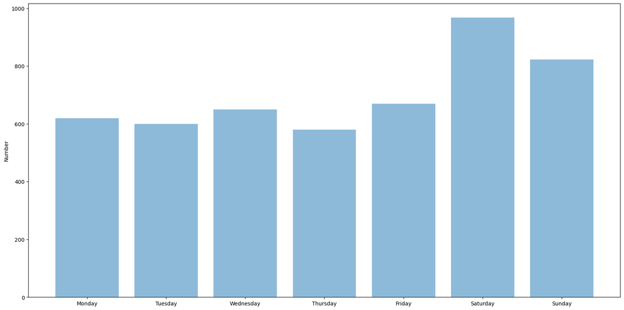

```
0
```

```python
bar_chart(day_number,day_of_week)
```

### Graph 2: Number of Offenses Occuring Based on the month

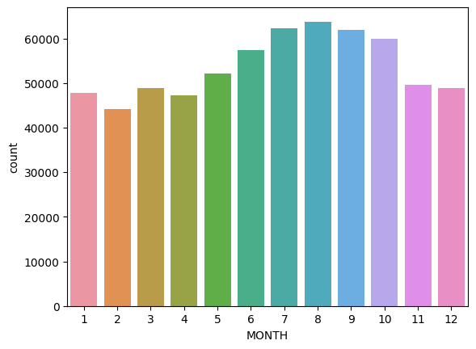

```python
sns.countplot(x=CrimeAll['MONTH'])
```

#### Graph Explanation 2:

The graph above shows the 12 months in the year and the number of count of crimes that occured on them. We can see based on the graph above starting in June there is a spike across the summer months of increased crime in Boston. Our assumption is that there is an increase in crimes occuring during the summer months due to increased number of people out due to the nicer weather in Boston. We see in the cooler months though there are less crimes occuring such as the jump from October(60,000 occurences) to Novemeber (50,000 occurences).

### Graph 3:Crime Occurences Based On The Time of Day

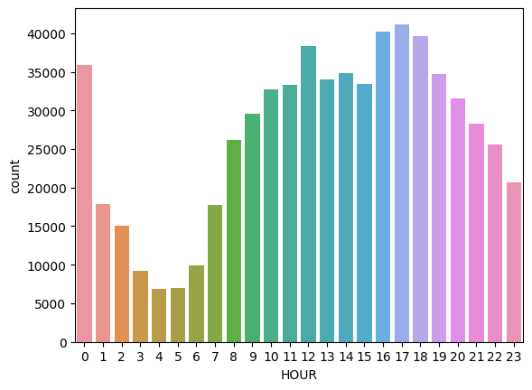

```python
sns.countplot(x=CrimeAll['HOUR'])
```

#### Graph Explanation 3:

Based on the graph above, we can see that crime in Boston tends to occur in the late afternoon/early evening. Crime seems to peak at 12PM and then dip down mid-afternoon and then there is another peak in early evening 4-6PM. What intrigued our group was that there was spike specifically at midnight and then it trends downwards into the early morning (1AM-6AM).

### Graph 4: Pie Chart Of How Many Crimes Have Occured Based On The Year

```python
def create_list_number_crime(name_column, list_unique):
    # list_unique = df[name_column].unique()

    i = 0

    list_number = list()

    while i < len(list_unique):
        list_number.append(len(CrimeAll.loc[CrimeAll[name_column] == list_unique[i]]))
        i += 1

    return list_unique, list_number
```

```python
list_unique_year, list_number_year = create_list_number_crime('YEAR',CrimeAll['YEAR'].unique())
```

```python
def create_list_number_crime(name_column, list_unique):
    # list_unique = df[name_column].unique()

    i = 0

    list_number = list()

    while i < len(list_unique):
        list_number.append(len(CrimeAll.loc[CrimeAll[name_column] == list_unique[i]]))
        i += 1

    return (list_unique, list_number
,CrimeAll['YEAR'].unique())
    return 0
```

```python
def pie_plot(list_number, list_unique):
    plt.figure(figsize=(20,10))
    plt.pie(list_unique,
        labels=list_number,
        autopct='%1.1f%%',
        shadow=True,
        startangle=140)

    plt.axis('equal')
    plt.show()
    return 0
```

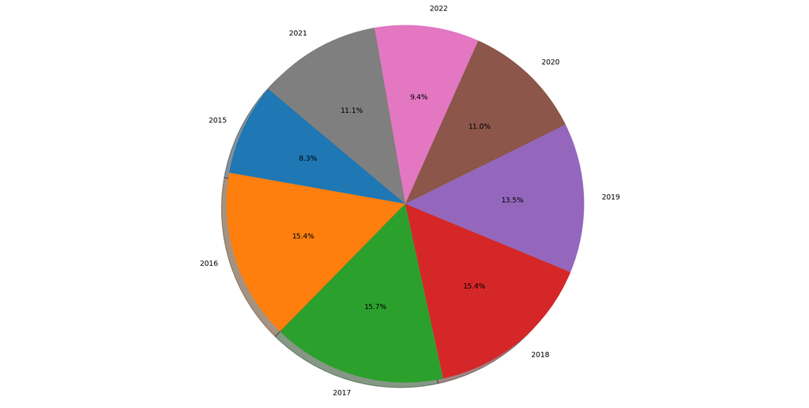

```
0
```

```python
pie_plot(list_unique_year, list_number_year)
```

#### Graph Explanation 4:

Based on the data above crime has significantly decreased over the years. There was a sharp increase in crime ocurring from 2015 to 2016 but we see it start to drop starting 2018 whereit reaches a low of 9.4% in 2022.

### Graph 5: Crime Occurences Based On District

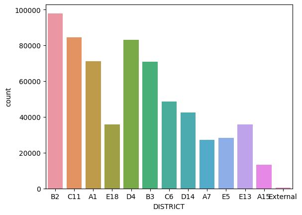

```python
sns.countplot(x=CrimeAll['DISTRICT'])
```

### Regression Analysis

```python
CrimeAll
```

|  | INCIDENT_NUMBER | OFFENSE_CODE | OFFENSE_DESCRIPTION | DISTRICT | REPORTING_AREA | SHOOTING | OCCURRED_ON_DATE | YEAR | MONTH | DAY_OF_WEEK | HOUR | STREET | Lat | Long | Location |
| --- | --- | --- | --- | --- | --- | --- | --- | --- | --- | --- | --- | --- | --- | --- | --- |
| 0 | I192068249 | 2647 | THREATS TO DO BODILY HARM | B2 | 280 | 0 | 2015-08-28 10:20:00 | 2015 | 8 | Friday | 10 | WASHINGTON ST | 42.330119 | -71.084251 | 42.33011862, -71.08425106 |
| 1 | I192061894 | 1106 | FRAUD - CREDIT CARD / ATM FRAUD | C11 | 356 | 0 | 2015-08-20 00:00:00 | 2015 | 8 | Thursday | 0 | CHARLES ST | 42.300605 | -71.061268 | 42.30060543, -71.06126785 |
| 2 | I192038828 | 1107 | FRAUD - IMPERSONATION | A1 | 172 | 0 | 2015-11-02 12:24:00 | 2015 | 11 | Monday | 12 | ALBANY ST | 42.334288 | -71.072395 | 42.33428841, -71.07239518 |
| 3 | I192008877 | 1107 | FRAUD - IMPERSONATION | E18 | 525 | 0 | 2015-07-31 10:00:00 | 2015 | 7 | Friday | 10 | WINGATE RD | 42.237009 | -71.129566 | 42.23700950, -71.12956606 |
| 4 | I182090828 | 1102 | FRAUD - FALSE PRETENSE / SCHEME | D4 | 159 | 0 | 2015-12-01 12:00:00 | 2015 | 12 | Tuesday | 12 | UPTON ST | 42.342432 | -71.072258 | 42.34243222, -71.07225766 |
| ... | ... | ... | ... | ... | ... | ... | ... | ... | ... | ... | ... | ... | ... | ... | ... |
| 71716 | 121005808 | 1102 | FRAUD - FALSE PRETENSE / SCHEME | B3 | 289 | 0 | 2021-01-19 12:00:00 | 2021 | 1 | Tuesday | 12 | CLARKWOOD ST | 42.333679 | -71.091878 | 42.33367921810846, -71.09187754618458 |
| 71717 | 121000816 | 3304 | NOISY PARTY/RADIO-NO ARREST | E5 | 675 | 0 | 2021-01-04 00:00:00 | 2021 | 1 | Monday | 0 | BRADFIELD AVENUE | 0.000000 | 0.000000 | 0, 0 |
| 71718 | 120221042 | 3006 | SICK/INJURED/MEDICAL - PERSON | E5 | 680 | 0 | 2021-04-02 10:45:00 | 2021 | 4 | Friday | 10 | WASHINGTON ST | 42.283902 | -71.130863 | 42.283902436483125, -71.13086262643496 |
| 71719 | 10637224 | 3125 | WARRANT ARREST - BOSTON WARRANT (MUST BE SUPPL... | D4 | 270 | 0 | 2021-01-26 18:54:00 | 2021 | 1 | Tuesday | 18 | NORTHAMPTON ST | 42.333951 | -71.075389 | 42.333951248393774, -71.07538938822692 |
| 71720 | 23844463 | 3115 | INVESTIGATE PERSON | C6 |  | 0 | 2021-10-16 01:16:00 | 2021 | 10 | Saturday | 1 | G ST & E 8TH ST\nBOSTON MA 02127\nUNITED STATES | 42.331320 | -71.044080 | 42.33132003900925, -71.04407996166562 |

643743 rows × 15 columns

```python
CrimeAll['OFFENSE_CODE'].unique()
```

```
array([ 2647,  1106,  1107,  1102,  2629,  3201,  2670,  3170,   619,
         735,   615,  3115,  3110,  1109,  3125,   724,  2007,   617,
        1108,  3207,   361,  3109,   614,   613,  1501,  3018,   802,
        3502,  3501,  1201,   616,  3208,  3831,   520,  1001,  2619,
        1402,  3114,   670,   727,   413,  3205,   706,  2610,  3805,
         801,  2005,  3119,  2623,   522,  3301,  3130,  2660,  2914,
        3112,  3620,  3802,   540,  3820,   301,  3810,  2632,  3410,
         562,   521,  3111,  3803,  2905,  3006,  3801,  3001,  1874,
        1849,  2900,  1810,  1841,  1843,  3160,  3007,  3830,  1848,
        1503,  2405,  3002,  1830,  3807,   423,  2604,  3403,  1504,
         612,  2403,  2907,  2906,   560,  2407,  3008,  1415,  1825,
         611,  1847,  1832,  1842,  3811,  2006,  2101,  2662,  3106,
        3305,  1845,  1304,  1815,  1300,   111,  1806,  1831,  2204,
         311,  2616,  3821,  3503,   542,  3108,  3304,  1510,  3122,
         371,  1846,  2511,  1805,  3625,  2646,  2648,  1844,  2613,
        3202,   804,   351,  3402,  2641,  2401,  2608,  1870,  2612,
        3302,  2003,  2663,  3016,  2657,  3102,  3004,   381,  1901,
        1601,  1850,  2004,  2102,  1602,  3123,   900,  2628,  1502,
         561,  3303,   541,  2617,   618,  2622,  2636,  2631,  3203,
        2605,  1605,  3029,  3116,  2642,  2664,  2611,  2618,  1603,
         624,  1863,   633,   349,   432,  1002,   315,   803,   334,
        2910,   637,   639,   403,   511,  1105,   623,   547,  1866,
         530,   339,  2010,  2609,  1807,   121,  1610,  1620,   123,
         112,   404,   770,   627,   629,  1302,   634,   402,   714,
         527,   338,  2672,  2606,   335,  1864,  3126,   800,   600,
         500,  1000,   400,   700,  3000,  2600,  3100,  1200,  2950,
        1400,  3300,  1100,  1800,  1500,   650,   300,  3350,  3200,
        2400,  3005,   641,   531,   736,   100,  2500,  2671, 99999,
         990,   122], dtype=int64)
```

```python
y = CrimeAll['SHOOTING']
y
```

```
0        0
1        0
2        0
3        0
4        0
        ..
71716    0
71717    0
71718    0
71719    0
71720    0
Name: SHOOTING, Length: 643743, dtype: int64
```

```python
X1=pd.get_dummies(CrimeAll['DISTRICT'])
X2=pd.get_dummies(CrimeAll['YEAR'])
X3=pd.get_dummies(CrimeAll['DAY_OF_WEEK'])
FinalX = pd.concat([CrimeAll,X1,X2,X3], axis=1)
FinalX
```

|  | INCIDENT_NUMBER | OFFENSE_CODE | OFFENSE_DESCRIPTION | DISTRICT | REPORTING_AREA | SHOOTING | OCCURRED_ON_DATE | YEAR | MONTH | DAY_OF_WEEK | ... | 2020 | 2021 | 2022 | Friday | Monday | Saturday | Sunday | Thursday | Tuesday | Wednesday |
| --- | --- | --- | --- | --- | --- | --- | --- | --- | --- | --- | --- | --- | --- | --- | --- | --- | --- | --- | --- | --- | --- |
| 0 | I192068249 | 2647 | THREATS TO DO BODILY HARM | B2 | 280 | 0 | 2015-08-28 10:20:00 | 2015 | 8 | Friday | ... | 0 | 0 | 0 | 1 | 0 | 0 | 0 | 0 | 0 | 0 |
| 1 | I192061894 | 1106 | FRAUD - CREDIT CARD / ATM FRAUD | C11 | 356 | 0 | 2015-08-20 00:00:00 | 2015 | 8 | Thursday | ... | 0 | 0 | 0 | 0 | 0 | 0 | 0 | 1 | 0 | 0 |
| 2 | I192038828 | 1107 | FRAUD - IMPERSONATION | A1 | 172 | 0 | 2015-11-02 12:24:00 | 2015 | 11 | Monday | ... | 0 | 0 | 0 | 0 | 1 | 0 | 0 | 0 | 0 | 0 |
| 3 | I192008877 | 1107 | FRAUD - IMPERSONATION | E18 | 525 | 0 | 2015-07-31 10:00:00 | 2015 | 7 | Friday | ... | 0 | 0 | 0 | 1 | 0 | 0 | 0 | 0 | 0 | 0 |
| 4 | I182090828 | 1102 | FRAUD - FALSE PRETENSE / SCHEME | D4 | 159 | 0 | 2015-12-01 12:00:00 | 2015 | 12 | Tuesday | ... | 0 | 0 | 0 | 0 | 0 | 0 | 0 | 0 | 1 | 0 |
| ... | ... | ... | ... | ... | ... | ... | ... | ... | ... | ... | ... | ... | ... | ... | ... | ... | ... | ... | ... | ... | ... |
| 71716 | 121005808 | 1102 | FRAUD - FALSE PRETENSE / SCHEME | B3 | 289 | 0 | 2021-01-19 12:00:00 | 2021 | 1 | Tuesday | ... | 0 | 1 | 0 | 0 | 0 | 0 | 0 | 0 | 1 | 0 |
| 71717 | 121000816 | 3304 | NOISY PARTY/RADIO-NO ARREST | E5 | 675 | 0 | 2021-01-04 00:00:00 | 2021 | 1 | Monday | ... | 0 | 1 | 0 | 0 | 1 | 0 | 0 | 0 | 0 | 0 |
| 71718 | 120221042 | 3006 | SICK/INJURED/MEDICAL - PERSON | E5 | 680 | 0 | 2021-04-02 10:45:00 | 2021 | 4 | Friday | ... | 0 | 1 | 0 | 1 | 0 | 0 | 0 | 0 | 0 | 0 |
| 71719 | 10637224 | 3125 | WARRANT ARREST - BOSTON WARRANT (MUST BE SUPPL... | D4 | 270 | 0 | 2021-01-26 18:54:00 | 2021 | 1 | Tuesday | ... | 0 | 1 | 0 | 0 | 0 | 0 | 0 | 0 | 1 | 0 |
| 71720 | 23844463 | 3115 | INVESTIGATE PERSON | C6 |  | 0 | 2021-10-16 01:16:00 | 2021 | 10 | Saturday | ... | 0 | 1 | 0 | 0 | 0 | 1 | 0 | 0 | 0 | 0 |

643743 rows × 43 columns

```python
FinalX=FinalX.drop(['SHOOTING','OFFENSE_CODE','Location','STREET','OCCURRED_ON_DATE','REPORTING_AREA','INCIDENT_NUMBER','OFFENSE_DESCRIPTION','DISTRICT','YEAR','DAY_OF_WEEK'], axis=1)
FinalX
```

|  | MONTH | HOUR | Lat | Long | A1 | A15 | A7 | B2 | B3 | C11 | ... | 2020 | 2021 | 2022 | Friday | Monday | Saturday | Sunday | Thursday | Tuesday | Wednesday |
| --- | --- | --- | --- | --- | --- | --- | --- | --- | --- | --- | --- | --- | --- | --- | --- | --- | --- | --- | --- | --- | --- |
| 0 | 8 | 10 | 42.330119 | -71.084251 | 0 | 0 | 0 | 1 | 0 | 0 | ... | 0 | 0 | 0 | 1 | 0 | 0 | 0 | 0 | 0 | 0 |
| 1 | 8 | 0 | 42.300605 | -71.061268 | 0 | 0 | 0 | 0 | 0 | 1 | ... | 0 | 0 | 0 | 0 | 0 | 0 | 0 | 1 | 0 | 0 |
| 2 | 11 | 12 | 42.334288 | -71.072395 | 1 | 0 | 0 | 0 | 0 | 0 | ... | 0 | 0 | 0 | 0 | 1 | 0 | 0 | 0 | 0 | 0 |
| 3 | 7 | 10 | 42.237009 | -71.129566 | 0 | 0 | 0 | 0 | 0 | 0 | ... | 0 | 0 | 0 | 1 | 0 | 0 | 0 | 0 | 0 | 0 |
| 4 | 12 | 12 | 42.342432 | -71.072258 | 0 | 0 | 0 | 0 | 0 | 0 | ... | 0 | 0 | 0 | 0 | 0 | 0 | 0 | 0 | 1 | 0 |
| ... | ... | ... | ... | ... | ... | ... | ... | ... | ... | ... | ... | ... | ... | ... | ... | ... | ... | ... | ... | ... | ... |
| 71716 | 1 | 12 | 42.333679 | -71.091878 | 0 | 0 | 0 | 0 | 1 | 0 | ... | 0 | 1 | 0 | 0 | 0 | 0 | 0 | 0 | 1 | 0 |
| 71717 | 1 | 0 | 0.000000 | 0.000000 | 0 | 0 | 0 | 0 | 0 | 0 | ... | 0 | 1 | 0 | 0 | 1 | 0 | 0 | 0 | 0 | 0 |
| 71718 | 4 | 10 | 42.283902 | -71.130863 | 0 | 0 | 0 | 0 | 0 | 0 | ... | 0 | 1 | 0 | 1 | 0 | 0 | 0 | 0 | 0 | 0 |
| 71719 | 1 | 18 | 42.333951 | -71.075389 | 0 | 0 | 0 | 0 | 0 | 0 | ... | 0 | 1 | 0 | 0 | 0 | 0 | 0 | 0 | 1 | 0 |
| 71720 | 10 | 1 | 42.331320 | -71.044080 | 0 | 0 | 0 | 0 | 0 | 0 | ... | 0 | 1 | 0 | 0 | 0 | 1 | 0 | 0 | 0 | 0 |

643743 rows × 32 columns

```python
FinalX.dtypes
```

```
MONTH          int64
HOUR           int64
Lat          float64
Long         float64
A1             uint8
A15            uint8
A7             uint8
B2             uint8
B3             uint8
C11            uint8
C6             uint8
D14            uint8
D4             uint8
E13            uint8
E18            uint8
E5             uint8
External       uint8
2015           uint8
2016           uint8
2017           uint8
2018           uint8
2019           uint8
2020           uint8
2021           uint8
2022           uint8
Friday         uint8
Monday         uint8
Saturday       uint8
Sunday         uint8
Thursday       uint8
Tuesday        uint8
Wednesday      uint8
dtype: object
```

```python
FinalX
```

|  | MONTH | HOUR | Lat | Long | A1 | A15 | A7 | B2 | B3 | C11 | ... | 2020 | 2021 | 2022 | Friday | Monday | Saturday | Sunday | Thursday | Tuesday | Wednesday |
| --- | --- | --- | --- | --- | --- | --- | --- | --- | --- | --- | --- | --- | --- | --- | --- | --- | --- | --- | --- | --- | --- |
| 0 | 8 | 10 | 42.330119 | -71.084251 | 0 | 0 | 0 | 1 | 0 | 0 | ... | 0 | 0 | 0 | 1 | 0 | 0 | 0 | 0 | 0 | 0 |
| 1 | 8 | 0 | 42.300605 | -71.061268 | 0 | 0 | 0 | 0 | 0 | 1 | ... | 0 | 0 | 0 | 0 | 0 | 0 | 0 | 1 | 0 | 0 |
| 2 | 11 | 12 | 42.334288 | -71.072395 | 1 | 0 | 0 | 0 | 0 | 0 | ... | 0 | 0 | 0 | 0 | 1 | 0 | 0 | 0 | 0 | 0 |
| 3 | 7 | 10 | 42.237009 | -71.129566 | 0 | 0 | 0 | 0 | 0 | 0 | ... | 0 | 0 | 0 | 1 | 0 | 0 | 0 | 0 | 0 | 0 |
| 4 | 12 | 12 | 42.342432 | -71.072258 | 0 | 0 | 0 | 0 | 0 | 0 | ... | 0 | 0 | 0 | 0 | 0 | 0 | 0 | 0 | 1 | 0 |
| ... | ... | ... | ... | ... | ... | ... | ... | ... | ... | ... | ... | ... | ... | ... | ... | ... | ... | ... | ... | ... | ... |
| 71716 | 1 | 12 | 42.333679 | -71.091878 | 0 | 0 | 0 | 0 | 1 | 0 | ... | 0 | 1 | 0 | 0 | 0 | 0 | 0 | 0 | 1 | 0 |
| 71717 | 1 | 0 | 0.000000 | 0.000000 | 0 | 0 | 0 | 0 | 0 | 0 | ... | 0 | 1 | 0 | 0 | 1 | 0 | 0 | 0 | 0 | 0 |
| 71718 | 4 | 10 | 42.283902 | -71.130863 | 0 | 0 | 0 | 0 | 0 | 0 | ... | 0 | 1 | 0 | 1 | 0 | 0 | 0 | 0 | 0 | 0 |
| 71719 | 1 | 18 | 42.333951 | -71.075389 | 0 | 0 | 0 | 0 | 0 | 0 | ... | 0 | 1 | 0 | 0 | 0 | 0 | 0 | 0 | 1 | 0 |
| 71720 | 10 | 1 | 42.331320 | -71.044080 | 0 | 0 | 0 | 0 | 0 | 0 | ... | 0 | 1 | 0 | 0 | 0 | 1 | 0 | 0 | 0 | 0 |

643743 rows × 32 columns

```python
FinalX.info()
```

```
<class 'pandas.core.frame.DataFrame'>
Int64Index: 643743 entries, 0 to 71720
Data columns (total 32 columns):
 #   Column     Non-Null Count   Dtype
---  ------     --------------   -----
 0   MONTH      643743 non-null  int64
 1   HOUR       643743 non-null  int64
 2   Lat        643743 non-null  float64
 3   Long       643743 non-null  float64
 4   A1         643743 non-null  uint8
 5   A15        643743 non-null  uint8
 6   A7         643743 non-null  uint8
 7   B2         643743 non-null  uint8
 8   B3         643743 non-null  uint8
 9   C11        643743 non-null  uint8
```

[output cut: 24 more lines]

```python
FinalX['Const'] = 1
```

```python
FinalX.info()
```

```
<class 'pandas.core.frame.DataFrame'>
Int64Index: 643743 entries, 0 to 71720
Data columns (total 33 columns):
 #   Column     Non-Null Count   Dtype
---  ------     --------------   -----
 0   MONTH      643743 non-null  int64
 1   HOUR       643743 non-null  int64
 2   Lat        643743 non-null  float64
 3   Long       643743 non-null  float64
 4   A1         643743 non-null  uint8
 5   A15        643743 non-null  uint8
 6   A7         643743 non-null  uint8
 7   B2         643743 non-null  uint8
 8   B3         643743 non-null  uint8
 9   C11        643743 non-null  uint8
```

[output cut: 25 more lines]

```python
y
```

```
0        0
1        0
2        0
3        0
4        0
        ..
71716    0
71717    0
71718    0
71719    0
71720    0
Name: SHOOTING, Length: 643743, dtype: int64
```

```python
# Import modules
import pandas as pd
import numpy as np
import statsmodels.api as sm
import matplotlib.pyplot as plt
import seaborn as sb

# Describe the linear model
mod = sm.Logit(y,FinalX)

# Fit model
fit = mod.fit()

# Summarize model
fit.summary()
```

```
Optimization terminated successfully.
         Current function value: 0.041074
         Iterations 11
```

Logit Regression Results

| Dep. Variable: | SHOOTING | No. Observations: | 643743 |
| --- | --- | --- | --- |
| Model: | Logit | Df Residuals: | 643712 |
| Method: | MLE | Df Model: | 30 |
| Date: | Sun, 04 Dec 2022 | Pseudo R-squ.: | 0.08310 |
| Time: | 16:19:28 | Log-Likelihood: | -26441. |
| converged: | True | LL-Null: | -28837. |
| Covariance Type: | nonrobust | LLR p-value: | 0.000 |

|  | coef | std err | z | P>\|z\| | [0.025 | 0.975] |
| --- | --- | --- | --- | --- | --- | --- |
| MONTH | 0.0227 | 0.004 | 5.095 | 0.000 | 0.014 | 0.031 |
| HOUR | -0.0046 | 0.002 | -2.088 | 0.037 | -0.009 | -0.000 |
| Lat | 0.0166 | 0.070 | 0.237 | 0.812 | -0.120 | 0.154 |
| Long | 0.0032 | 0.042 | 0.076 | 0.940 | -0.078 | 0.085 |
| A1 | -2.0773 | 0.220 | -9.441 | 0.000 | -2.508 | -1.646 |
| A15 | -1.1152 | 0.254 | -4.391 | 0.000 | -1.613 | -0.617 |
| A7 | -0.8109 | 0.210 | -3.861 | 0.000 | -1.223 | -0.399 |
| B2 | 0.7479 | 0.184 | 4.071 | 0.000 | 0.388 | 1.108 |
| B3 | 0.9077 | 0.184 | 4.936 | 0.000 | 0.547 | 1.268 |
| C11 | 0.3973 | 0.185 | 2.149 | 0.032 | 0.035 | 0.760 |
| C6 | -0.8098 | 0.198 | -4.089 | 0.000 | -1.198 | -0.422 |
| D14 | -1.3019 | 0.211 | -6.175 | 0.000 | -1.715 | -0.889 |
| D4 | -0.8871 | 0.192 | -4.609 | 0.000 | -1.264 | -0.510 |
| E13 | 0.0269 | 0.192 | 0.140 | 0.889 | -0.349 | 0.403 |
| E18 | -0.0972 | 0.193 | -0.504 | 0.614 | -0.475 | 0.281 |
| E5 | -0.8902 | 0.210 | -4.229 | 0.000 | -1.303 | -0.478 |
| External | -0.4464 | 0.534 | -0.836 | 0.403 | -1.493 | 0.600 |
| 2015 | -1.0206 | 6.62e+05 | -1.54e-06 | 1.000 | -1.3e+06 | 1.3e+06 |
| 2016 | -1.2712 | 6.62e+05 | -1.92e-06 | 1.000 | -1.3e+06 | 1.3e+06 |
| 2017 | -1.0048 | 6.62e+05 | -1.52e-06 | 1.000 | -1.3e+06 | 1.3e+06 |
| 2018 | -1.1146 | 6.62e+05 | -1.68e-06 | 1.000 | -1.3e+06 | 1.3e+06 |
| 2019 | -0.2596 | 6.62e+05 | -3.92e-07 | 1.000 | -1.3e+06 | 1.3e+06 |
| 2020 | 0.2807 | 6.62e+05 | 4.24e-07 | 1.000 | -1.3e+06 | 1.3e+06 |
| 2021 | 0.0813 | 6.62e+05 | 1.23e-07 | 1.000 | -1.3e+06 | 1.3e+06 |
| 2022 | -0.0937 | 6.62e+05 | -1.41e-07 | 1.000 | -1.3e+06 | 1.3e+06 |
| Friday | -0.7179 | 7.16e+05 | -1e-06 | 1.000 | -1.4e+06 | 1.4e+06 |
| Monday | -0.7639 | 7.16e+05 | -1.07e-06 | 1.000 | -1.4e+06 | 1.4e+06 |
| Saturday | -0.2549 | 7.16e+05 | -3.56e-07 | 1.000 | -1.4e+06 | 1.4e+06 |
| Sunday | -0.3325 | 7.16e+05 | -4.65e-07 | 1.000 | -1.4e+06 | 1.4e+06 |
| Thursday | -0.8278 | 7.16e+05 | -1.16e-06 | 1.000 | -1.4e+06 | 1.4e+06 |
| Tuesday | -0.7860 | 7.16e+05 | -1.1e-06 | 1.000 | -1.4e+06 | 1.4e+06 |
| Wednesday | -0.7195 | 7.16e+05 | -1.01e-06 | 1.000 | -1.4e+06 | 1.4e+06 |
| Const | -4.4026 | nan | nan | nan | nan | nan |

### Multicollinearity Check

```python
from statsmodels.stats.outliers_influence import variance_inflation_factor

# Calculate VIF
pd.Series([variance_inflation_factor(FinalX.values, i)
           for i in range(FinalX.shape[1])],
          index=FinalX.columns)
```

```
MONTH          1.063904
HOUR           1.003943
Lat          283.402123
Long         283.224534
A1            15.980593
A15            4.111805
A7             7.199916
B2            20.672292
B3            15.935156
C11           18.425627
C6            11.616777
D14           10.402204
D4            18.164000
E13            9.013994
E18            9.027479
E5             7.431550
External       1.123712
2015                inf
2016                inf
2017                inf
2018                inf
2019                inf
2020                inf
2021                inf
2022                inf
Friday              inf
Monday              inf
Saturday            inf
Sunday              inf
Thursday            inf
Tuesday             inf
Wednesday           inf
Const          0.000000
dtype: float64
```

### Predictive Modeling

```python
from sklearn.model_selection import train_test_split

# 20-80% simple split
train_y,test_y,train_X,test_X = train_test_split(y, FinalX,
                                                 test_size=0.2,
                                                 random_state=123)
```

```python
train_y.shape
```

```
(514994,)
```

```python
test_y.shape
```

```
(128749,)
```

```python
train_X.shape
```

```
(514994, 33)
```

```python
test_X.shape
```

```
(128749, 33)
```

## Normalize Data

```python
from sklearn import preprocessing

# Create a scaler to do the transformation
scaler = preprocessing.MinMaxScaler().fit(train_X)
```

```python
# Transform training X
train_X_scale = scaler.transform(train_X)
train_X_scale = pd.DataFrame(train_X_scale)
train_X_scale.columns = train_X.columns

train_X_scale.describe().transpose()
```

|  | count | mean | std | min | 25% | 50% | 75% | max |
| --- | --- | --- | --- | --- | --- | --- | --- | --- |
| MONTH | 514994.0 | 0.517685 | 0.301807 | 0.0 | 0.272727 | 0.545455 | 0.727273 | 1.0 |
| HOUR | 514994.0 | 0.564871 | 0.276372 | 0.0 | 0.391304 | 0.608696 | 0.782609 | 1.0 |
| Lat | 514994.0 | 0.981882 | 0.071926 | 0.0 | 0.998721 | 0.998953 | 0.999140 | 1.0 |
| Long | 514994.0 | 0.252308 | 0.177444 | 0.0 | 0.210043 | 0.210269 | 0.210447 | 1.0 |
| A1 | 514994.0 | 0.110658 | 0.313708 | 0.0 | 0.000000 | 0.000000 | 0.000000 | 1.0 |
| A15 | 514994.0 | 0.020862 | 0.142924 | 0.0 | 0.000000 | 0.000000 | 0.000000 | 1.0 |
| A7 | 514994.0 | 0.042224 | 0.201100 | 0.0 | 0.000000 | 0.000000 | 0.000000 | 1.0 |
| B2 | 514994.0 | 0.151802 | 0.358829 | 0.0 | 0.000000 | 0.000000 | 0.000000 | 1.0 |
| B3 | 514994.0 | 0.110170 | 0.313102 | 0.0 | 0.000000 | 0.000000 | 0.000000 | 1.0 |
| C11 | 514994.0 | 0.131450 | 0.337892 | 0.0 | 0.000000 | 0.000000 | 0.000000 | 1.0 |
| C6 | 514994.0 | 0.075156 | 0.263643 | 0.0 | 0.000000 | 0.000000 | 0.000000 | 1.0 |
| D14 | 514994.0 | 0.066110 | 0.248474 | 0.0 | 0.000000 | 0.000000 | 0.000000 | 1.0 |
| D4 | 514994.0 | 0.128949 | 0.335144 | 0.0 | 0.000000 | 0.000000 | 0.000000 | 1.0 |
| E13 | 514994.0 | 0.055517 | 0.228987 | 0.0 | 0.000000 | 0.000000 | 0.000000 | 1.0 |
| E18 | 514994.0 | 0.055723 | 0.229386 | 0.0 | 0.000000 | 0.000000 | 0.000000 | 1.0 |
| E5 | 514994.0 | 0.043857 | 0.204777 | 0.0 | 0.000000 | 0.000000 | 0.000000 | 1.0 |
| External | 514994.0 | 0.000802 | 0.028307 | 0.0 | 0.000000 | 0.000000 | 0.000000 | 1.0 |
| 2015 | 514994.0 | 0.083129 | 0.276078 | 0.0 | 0.000000 | 0.000000 | 0.000000 | 1.0 |
| 2016 | 514994.0 | 0.154751 | 0.361668 | 0.0 | 0.000000 | 0.000000 | 0.000000 | 1.0 |
| 2017 | 514994.0 | 0.157347 | 0.364128 | 0.0 | 0.000000 | 0.000000 | 0.000000 | 1.0 |
| 2018 | 514994.0 | 0.153872 | 0.360826 | 0.0 | 0.000000 | 0.000000 | 0.000000 | 1.0 |
| 2019 | 514994.0 | 0.135404 | 0.342154 | 0.0 | 0.000000 | 0.000000 | 0.000000 | 1.0 |
| 2020 | 514994.0 | 0.110093 | 0.313005 | 0.0 | 0.000000 | 0.000000 | 0.000000 | 1.0 |
| 2021 | 514994.0 | 0.111304 | 0.314509 | 0.0 | 0.000000 | 0.000000 | 0.000000 | 1.0 |
| 2022 | 514994.0 | 0.094100 | 0.291968 | 0.0 | 0.000000 | 0.000000 | 0.000000 | 1.0 |
| Friday | 514994.0 | 0.152256 | 0.359269 | 0.0 | 0.000000 | 0.000000 | 0.000000 | 1.0 |
| Monday | 514994.0 | 0.143662 | 0.350747 | 0.0 | 0.000000 | 0.000000 | 0.000000 | 1.0 |
| Saturday | 514994.0 | 0.141105 | 0.348130 | 0.0 | 0.000000 | 0.000000 | 0.000000 | 1.0 |
| Sunday | 514994.0 | 0.126283 | 0.332168 | 0.0 | 0.000000 | 0.000000 | 0.000000 | 1.0 |
| Thursday | 514994.0 | 0.145874 | 0.352980 | 0.0 | 0.000000 | 0.000000 | 0.000000 | 1.0 |
| Tuesday | 514994.0 | 0.144209 | 0.351302 | 0.0 | 0.000000 | 0.000000 | 0.000000 | 1.0 |
| Wednesday | 514994.0 | 0.146611 | 0.353718 | 0.0 | 0.000000 | 0.000000 | 0.000000 | 1.0 |
| Const | 514994.0 | 0.000000 | 0.000000 | 0.0 | 0.000000 | 0.000000 | 0.000000 | 0.0 |

```python
# Transform test X
test_X_scale = scaler.transform(test_X)
test_X_scale = pd.DataFrame(test_X_scale)
test_X_scale.columns = test_X.columns

test_X_scale.describe().transpose()
```

|  | count | mean | std | min | 25% | 50% | 75% | max |
| --- | --- | --- | --- | --- | --- | --- | --- | --- |
| MONTH | 128749.0 | 0.518426 | 0.301931 | 0.0 | 0.272727 | 0.545455 | 0.727273 | 1.000000 |
| HOUR | 128749.0 | 0.564150 | 0.276884 | 0.0 | 0.391304 | 0.608696 | 0.782609 | 1.000000 |
| Lat | 128749.0 | 0.981555 | 0.072661 | 0.0 | 0.998717 | 0.998952 | 0.999139 | 0.999499 |
| Long | 128749.0 | 0.253063 | 0.178949 | 0.0 | 0.210044 | 0.210268 | 0.210447 | 1.000000 |
| A1 | 128749.0 | 0.110727 | 0.313795 | 0.0 | 0.000000 | 0.000000 | 0.000000 | 1.000000 |
| A15 | 128749.0 | 0.020365 | 0.141247 | 0.0 | 0.000000 | 0.000000 | 0.000000 | 1.000000 |
| A7 | 128749.0 | 0.042323 | 0.201325 | 0.0 | 0.000000 | 0.000000 | 0.000000 | 1.000000 |
| B2 | 128749.0 | 0.153112 | 0.360097 | 0.0 | 0.000000 | 0.000000 | 0.000000 | 1.000000 |
| B3 | 128749.0 | 0.109205 | 0.311897 | 0.0 | 0.000000 | 0.000000 | 0.000000 | 1.000000 |
| C11 | 128749.0 | 0.130316 | 0.336652 | 0.0 | 0.000000 | 0.000000 | 0.000000 | 1.000000 |
| C6 | 128749.0 | 0.075830 | 0.264726 | 0.0 | 0.000000 | 0.000000 | 0.000000 | 1.000000 |
| D14 | 128749.0 | 0.064777 | 0.246133 | 0.0 | 0.000000 | 0.000000 | 0.000000 | 1.000000 |
| D4 | 128749.0 | 0.130199 | 0.336524 | 0.0 | 0.000000 | 0.000000 | 0.000000 | 1.000000 |
| E13 | 128749.0 | 0.055612 | 0.229172 | 0.0 | 0.000000 | 0.000000 | 0.000000 | 1.000000 |
| E18 | 128749.0 | 0.055527 | 0.229006 | 0.0 | 0.000000 | 0.000000 | 0.000000 | 1.000000 |
| E5 | 128749.0 | 0.044777 | 0.206815 | 0.0 | 0.000000 | 0.000000 | 0.000000 | 1.000000 |
| External | 128749.0 | 0.000847 | 0.029084 | 0.0 | 0.000000 | 0.000000 | 0.000000 | 1.000000 |
| 2015 | 128749.0 | 0.083775 | 0.277052 | 0.0 | 0.000000 | 0.000000 | 0.000000 | 1.000000 |
| 2016 | 128749.0 | 0.153275 | 0.360254 | 0.0 | 0.000000 | 0.000000 | 0.000000 | 1.000000 |
| 2017 | 128749.0 | 0.157710 | 0.364470 | 0.0 | 0.000000 | 0.000000 | 0.000000 | 1.000000 |
| 2018 | 128749.0 | 0.152584 | 0.359587 | 0.0 | 0.000000 | 0.000000 | 0.000000 | 1.000000 |
| 2019 | 128749.0 | 0.135551 | 0.342312 | 0.0 | 0.000000 | 0.000000 | 0.000000 | 1.000000 |
| 2020 | 128749.0 | 0.110269 | 0.313226 | 0.0 | 0.000000 | 0.000000 | 0.000000 | 1.000000 |
| 2021 | 128749.0 | 0.111846 | 0.315178 | 0.0 | 0.000000 | 0.000000 | 0.000000 | 1.000000 |
| 2022 | 128749.0 | 0.094991 | 0.293204 | 0.0 | 0.000000 | 0.000000 | 0.000000 | 1.000000 |
| Friday | 128749.0 | 0.152545 | 0.359550 | 0.0 | 0.000000 | 0.000000 | 0.000000 | 1.000000 |
| Monday | 128749.0 | 0.144793 | 0.351894 | 0.0 | 0.000000 | 0.000000 | 0.000000 | 1.000000 |
| Saturday | 128749.0 | 0.139760 | 0.346740 | 0.0 | 0.000000 | 0.000000 | 0.000000 | 1.000000 |
| Sunday | 128749.0 | 0.127636 | 0.333685 | 0.0 | 0.000000 | 0.000000 | 0.000000 | 1.000000 |
| Thursday | 128749.0 | 0.145586 | 0.352692 | 0.0 | 0.000000 | 0.000000 | 0.000000 | 1.000000 |
| Tuesday | 128749.0 | 0.143170 | 0.350248 | 0.0 | 0.000000 | 0.000000 | 0.000000 | 1.000000 |
| Wednesday | 128749.0 | 0.146510 | 0.353618 | 0.0 | 0.000000 | 0.000000 | 0.000000 | 1.000000 |
| Const | 128749.0 | 0.000000 | 0.000000 | 0.0 | 0.000000 | 0.000000 | 0.000000 | 0.000000 |

## k-Nearest Neighbors (k-NN): Model 1

```python
from sklearn import neighbors

knn5 = neighbors.KNeighborsClassifier(n_neighbors=5)
```

```python
knn5.fit(train_X_scale, train_y)
```

```
KNeighborsClassifier()
```

```python
pred_y_knn5 = knn5.predict(test_X_scale)
```

```python
# Calculate classification accuracy
from sklearn import metrics

metrics.accuracy_score(test_y, pred_y_knn5)
```

```
0.9919844037623593
```

```python
# Calculate AUC
metrics.roc_auc_score(test_y, pred_y_knn5)
```

```
0.5529595956900832
```

```python
# Calculate Cohen's Kappa
metrics.cohen_kappa_score(test_y, pred_y_knn5)
```

```
0.17337364247014375
```

```python
# Print classification report
print(metrics.classification_report(test_y, pred_y_knn5))
```

```
              precision    recall  f1-score   support

           0       0.99      1.00      1.00    127719
           1       0.50      0.11      0.18      1030

    accuracy                           0.99    128749
   macro avg       0.74      0.55      0.59    128749
weighted avg       0.99      0.99      0.99    128749
```

### Tune kNN: Model 2

```python
for k in range(20):
    k = k + 1
    knn = neighbors.KNeighborsClassifier(n_neighbors = k,
                                         weights='uniform',
                                         algorithm='auto')
    knn.fit(train_X_scale, train_y)
    pred_y = knn.predict(test_X_scale)
    print("AUC is ", round(metrics.roc_auc_score(test_y, pred_y)*100,2),"% for k =",k)
```

```
AUC is  62.97 % for k = 1
```

```
AUC is  56.71 % for k = 2
```

```
AUC is  57.19 % for k = 3
```

```
AUC is  55.27 % for k = 4
```

```
AUC is  55.3 % for k = 5
```

```
AUC is  53.38 % for k = 6
```

```
AUC is  53.52 % for k = 7
```

```
AUC is  52.56 % for k = 8
```

```
AUC is  52.55 % for k = 9
```

```
AUC is  52.36 % for k = 10
```

```
AUC is  52.36 % for k = 11
```

```
AUC is  51.88 % for k = 12
```

```
AUC is  51.88 % for k = 13
```

```
AUC is  51.4 % for k = 14
```

```
AUC is  51.4 % for k = 15
```

```
AUC is  51.2 % for k = 16
```

```
AUC is  51.2 % for k = 17
```

```
AUC is  50.63 % for k = 18
```

```
AUC is  50.67 % for k = 19
```

```
AUC is  50.39 % for k = 20
```

```python
knn_final = neighbors.KNeighborsClassifier(n_neighbors = 1,
                                      weights='uniform',
                                      algorithm='auto')
knn_final.fit(train_X_scale, train_y)
pred_y_knn_final = knn_final.predict(test_X_scale)
```

```python
# Calculate classification accuracy
metrics.accuracy_score(test_y, pred_y_knn_final)
```

```
0.9875338837583204
```

```python
# Calculate AUC
metrics.roc_auc_score(test_y, pred_y_knn_final)
```

```
0.6296860059215251
```

```python
# Calculate Cohen's Kappa
metrics.cohen_kappa_score(test_y, pred_y_knn_final)
```

```
0.2482547779553962
```

```python
# Print classification report
print(metrics.classification_report(test_y, pred_y_knn_final))
```

```
              precision    recall  f1-score   support

           0       0.99      0.99      0.99    127719
           1       0.24      0.27      0.25      1030

    accuracy                           0.99    128749
   macro avg       0.62      0.63      0.62    128749
weighted avg       0.99      0.99      0.99    128749
```

## Model 3: Gaussian Naive Bayes

```python
# Gaussian Naive Bayes (GaussianNB) for classification. The likelihood of features is assumed to be Gaussian.
from sklearn import naive_bayes
gauss_nb = naive_bayes.GaussianNB()
```

```python
gauss_nb.fit(train_X, train_y)
```

```
GaussianNB()
```

```python
pred_y_gnb = gauss_nb.predict(test_X)
```

```python
# Calculate classification accuracy
metrics.accuracy_score(test_y, pred_y_gnb)
```

```
0.8043557619865008
```

```python
# Calculate AUC
metrics.roc_auc_score(test_y, pred_y_gnb)
```

```
0.6856671088540323
```

```python
# Calculate Cohen's Kappa
metrics.cohen_kappa_score(test_y, pred_y_gnb)
```

```
0.029244406433286074
```

```python
# Print classification report
print(metrics.classification_report(test_y, pred_y_gnb))
```

```
              precision    recall  f1-score   support

           0       1.00      0.81      0.89    127719
           1       0.02      0.57      0.04      1030

    accuracy                           0.80    128749
   macro avg       0.51      0.69      0.47    128749
weighted avg       0.99      0.80      0.88    128749
```

## Model 4: Bernoulli Naive Bayes

```python
# Naive Bayes classifier for multivariate Bernoulli models
bernou_nb = naive_bayes.BernoulliNB()
```

```python
bernou_nb.fit(train_X, train_y)
```

```
BernoulliNB()
```

```python
pred_y_bnb = bernou_nb.predict(test_X)
```

```python
# Calculate classification accuracy
metrics.accuracy_score(test_y, pred_y_bnb)
```

```
0.9919999378635951
```

```python
# Calculate AUC
metrics.roc_auc_score(test_y, pred_y_bnb)
```

```
0.5
```

```python
# Calculate Cohen's Kappa
metrics.cohen_kappa_score(test_y, pred_y_bnb)
```

```
0.0
```

```python
# Print classification report
print(metrics.classification_report(test_y, pred_y_bnb))
```

```
              precision    recall  f1-score   support

           0       0.99      1.00      1.00    127719
           1       0.00      0.00      0.00      1030

    accuracy                           0.99    128749
   macro avg       0.50      0.50      0.50    128749
weighted avg       0.98      0.99      0.99    128749
```

## Model 5: Decision Tree Classifier

```python
from sklearn import tree
# Decision trees for classification, use entropy criterion (gini by default)
dt = tree.DecisionTreeClassifier(criterion='entropy')
dt.fit(train_X, train_y)
```

```
DecisionTreeClassifier(criterion='entropy')
```

```python
pred_y_dt = dt.predict(test_X)
```

```python
# Calculate classification accuracy
metrics.accuracy_score(test_y, pred_y_dt)
```

```
0.9874096109484346
```

```python
# Calculate AUC
metrics.roc_auc_score(test_y, pred_y_dt)
```

```
0.6296233684126188
```

```python
# Calculate Cohen's Kappa
metrics.cohen_kappa_score(test_y, pred_y_dt)
```

```
0.24631848845200344
```

```python
# Print classification report
print(metrics.classification_report(test_y, pred_y_dt))
```

```
              precision    recall  f1-score   support

           0       0.99      0.99      0.99    127719
           1       0.24      0.27      0.25      1030

    accuracy                           0.99    128749
   macro avg       0.62      0.63      0.62    128749
weighted avg       0.99      0.99      0.99    128749
```

## Model 6: Random Forest

```python
from sklearn.ensemble import RandomForestClassifier
```

```python
# Train an RF classifier
rf = RandomForestClassifier(n_estimators=5, max_features=7, random_state=123)
```

```python
rf.fit(train_X,train_y)
```

```
RandomForestClassifier(max_features=7, n_estimators=5, random_state=123)
```

```python
# Show feature importance
rf.feature_importances_
```

```
array([1.37255950e-01, 1.27617239e-01, 2.87750124e-01, 2.86920511e-01,
       8.56842224e-04, 1.65808436e-04, 3.10437702e-04, 4.70335478e-03,
       3.77920341e-03, 5.03454719e-03, 2.15389376e-03, 1.07652819e-03,
       1.74836577e-03, 3.49687377e-03, 2.90940855e-03, 9.14698281e-04,
       1.16305480e-04, 5.50884722e-03, 3.79332382e-03, 6.65355410e-03,
       5.96057180e-03, 6.55590434e-03, 4.86820541e-03, 4.83654764e-03,
       4.67921226e-03, 1.21668903e-02, 1.19865680e-02, 1.34299678e-02,
       1.34829127e-02, 1.24663342e-02, 1.29431531e-02, 1.38579153e-02,
       0.00000000e+00])
```

```python
# Beautify the display of feature importance
feature_importances = pd.DataFrame(rf.feature_importances_,
                                   index = train_X.columns,
                                   columns=['importance'])
feature_importances = feature_importances.sort_values('importance',ascending=False)

feature_importances
```

|  | importance |
| --- | --- |
| Lat | 0.287750 |
| Long | 0.286921 |
| MONTH | 0.137256 |
| HOUR | 0.127617 |
| Wednesday | 0.013858 |
| Sunday | 0.013483 |
| Saturday | 0.013430 |
| Tuesday | 0.012943 |
| Thursday | 0.012466 |
| Friday | 0.012167 |
| Monday | 0.011987 |
| 2017 | 0.006654 |
| 2019 | 0.006556 |
| 2018 | 0.005961 |
| 2015 | 0.005509 |
| C11 | 0.005035 |
| 2020 | 0.004868 |
| 2021 | 0.004837 |
| B2 | 0.004703 |
| 2022 | 0.004679 |
| 2016 | 0.003793 |
| B3 | 0.003779 |
| E13 | 0.003497 |
| E18 | 0.002909 |
| C6 | 0.002154 |
| D4 | 0.001748 |
| D14 | 0.001077 |
| E5 | 0.000915 |
| A1 | 0.000857 |
| A7 | 0.000310 |
| A15 | 0.000166 |
| External | 0.000116 |
| Const | 0.000000 |

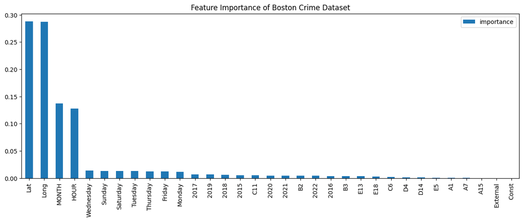

```python
feature_importances.plot(kind = 'bar',figsize=(15,5),
                         title='Feature Importance of Boston Crime Dataset')
```

```python
# Predict on test set
pred_y_rf = rf.predict(test_X)
```

```python
# Calculate classification accuracy
metrics.accuracy_score(test_y, pred_y_rf)
```

```
0.9926834383179676
```

```python
# Calculate AUC
metrics.roc_auc_score(test_y, pred_y_rf)
```

```
0.6014641365674052
```

```python
# Calculate Cohen's Kappa
metrics.cohen_kappa_score(test_y, pred_y_rf)
```

```
0.3056620028721455
```

```python
# Print classification report
print(metrics.classification_report(test_y, pred_y_rf))
```

```
              precision    recall  f1-score   support

           0       0.99      1.00      1.00    127719
           1       0.63      0.20      0.31      1030

    accuracy                           0.99    128749
   macro avg       0.81      0.60      0.65    128749
weighted avg       0.99      0.99      0.99    128749
```

### Summarize Findings

Based on our predictive modeling we have found that our best model is Gaussian Naive Bayers. The Gaussian Naive Bayers had an AUC of 0.6856671088540323 which was the highest out of all 6 models that we tuned.

For business improvement: Our visualizations shows us the hotspot centers for crime. Roxbury, Dorchestor, Southend, Downtown, Mattapan, South Boston and Brighton were observed to be most dangerous districts in the City of Boston, thus our visualization and predictive modeling of the BPD dataset provides stakeholders such as the Police Departments, Residents, landlords, business owners, government officials with ample information required for combating crime.

Police Department & Government Officials: We observed three categories for crime rates in the districts. That is, dangerous districts (Roxbury, Dorchestor, Southend, Downtown, Mattapan, South Boston and Brighton), moderately safe districts (Hyde Park and Jamaican Plain) and safe cities (West Roxbury, East Boston and Charlestown) with extremely low crime rates. Thus, the Police department and Government Officials are advised to channel more resources to the various hotspot centers.

Residents and Visitors: Residents of these hotspot centers are also advised to be alert at all times, move in groups, carry pepper sprays and other crime-combating tools permitted in the city. Visitors are therefore advised on the alarming crime rates expecially in the summer months and around the city's historical sites, thus they are advised to be very alert during the course of their visit.

Landlords and Business Owners: Landlords and business owners can use our visualizations to see where would be best to buy an apartment or business to avoid crime occuring at their business. This study also reveals that landlords and business owners in the hotspot centers in the City of Boston should consider the use of quality security systems when organizing apartments and their businesses.

```python
acc = [metrics.accuracy_score(test_y, pred_y_knn5),
       metrics.accuracy_score(test_y, pred_y_knn_final),
       metrics.accuracy_score(test_y, pred_y_gnb),
       metrics.accuracy_score(test_y, pred_y_bnb),
       metrics.accuracy_score(test_y, pred_y_dt),
       metrics.accuracy_score(test_y, pred_y_rf)]

pre = [metrics.precision_score(test_y, pred_y_knn5),
       metrics.precision_score(test_y, pred_y_knn_final),
       metrics.precision_score(test_y, pred_y_gnb),
       metrics.precision_score(test_y, pred_y_bnb),
       metrics.precision_score(test_y, pred_y_dt),
       metrics.precision_score(test_y, pred_y_rf)]

rec = [metrics.recall_score(test_y, pred_y_knn5),
       metrics.recall_score(test_y, pred_y_knn_final),
       metrics.recall_score(test_y, pred_y_gnb),
       metrics.recall_score(test_y, pred_y_bnb),
       metrics.recall_score(test_y, pred_y_dt),
       metrics.recall_score(test_y, pred_y_rf)]

f1  = [metrics.f1_score(test_y, pred_y_knn5),
       metrics.f1_score(test_y, pred_y_knn_final),
       metrics.f1_score(test_y, pred_y_gnb),
       metrics.f1_score(test_y, pred_y_bnb),
       metrics.f1_score(test_y, pred_y_dt),
       metrics.f1_score(test_y, pred_y_rf)]

auc  = [metrics.roc_auc_score(test_y, pred_y_knn5),
        metrics.roc_auc_score(test_y, pred_y_knn_final),
        metrics.roc_auc_score(test_y, pred_y_gnb),
        metrics.roc_auc_score(test_y, pred_y_bnb),
        metrics.roc_auc_score(test_y, pred_y_dt),
        metrics.roc_auc_score(test_y, pred_y_rf)]
```

```python
pd.DataFrame({'Accuracy':acc, 'Precision':pre, 'Recall':rec, 'F1 Score': f1, 'AUC':auc},
             index = ['k-NN (k=5)',
                      'k-NN (k=1)',
                      'Gaussian Naive Bayes',
                      'Bernoulli Naive Bayes',
                      'Decision Tree',
                      'RF without Hyperparameter Tunning'])
```

|  | Accuracy | Precision | Recall | F1 Score | AUC |
| --- | --- | --- | --- | --- | --- |
| k-NN (k=5) | 0.991984 | 0.495495 | 0.106796 | 0.175719 | 0.552960 |
| k-NN (k=1) | 0.987534 | 0.243989 | 0.266019 | 0.254529 | 0.629686 |
| Gaussian Naive Bayes | 0.804356 | 0.022983 | 0.565049 | 0.044170 | 0.685667 |
| Bernoulli Naive Bayes | 0.992000 | 0.000000 | 0.000000 | 0.000000 | 0.500000 |
| Decision Tree | 0.987410 | 0.240562 | 0.266019 | 0.252651 | 0.629623 |
| RF without Hyperparameter Tunning | 0.992683 | 0.632530 | 0.203883 | 0.308370 | 0.601464 |

### Citations

[Google Drive link to articles used](https://drive.google.com/drive/folders/1DP_FKYysny8n8pPRB1WJujy59_AgQAzb?usp=sharing)  
[Boston Crime Dataset](https://data.boston.gov/dataset/crime-incident-reports-august-2015-to-date-source-new-system/resource/313e56df-6d77-49d2-9c49-ee411f10cf58?inner_span=True)